# 3. Advanced Mapping

Paolo Di Lorenzo

2024-01-17

This vignette will explore some of the more advanced mapping features of `usmap`. Before continuing, be sure to check out Mapping the US as that will cover more of the basics of plotting US maps and styling them with `ggplot2`.

## Labels

As of `usmap 0.4.0`, maps with state labels can be created:

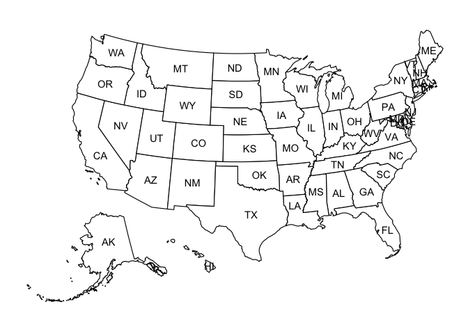

```r
usmap::plot_usmap("states", labels = TRUE)
```

`usmap 0.5.0` adds the ability to add county labels:

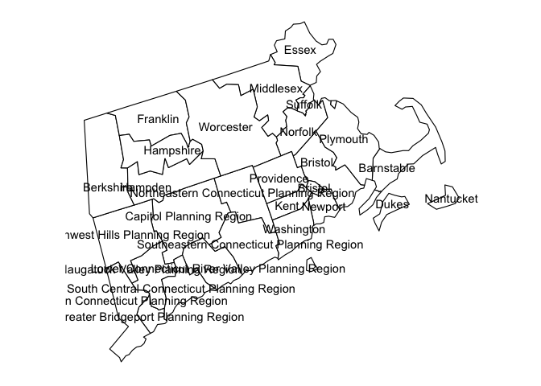

```r
usmap::plot_usmap("counties", include = c("MA", "CT", "RI"), labels = TRUE)
```

Labels can be colored using the `label_color` parameter:

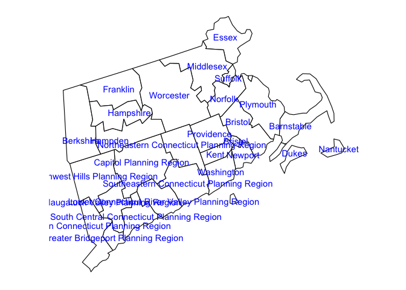

```r
usmap::plot_usmap("counties",
                  include = c("MA", "CT", "RI"),
                  labels = TRUE, label_color = "blue")
```

## `ggplot2` aesthetic mapping parameters

Parameters used by the map’s aesthetic mapping (`ggplot2::aes`) can be passed directly via `plot_usmap` by adding the parameters anywhere at the call site:

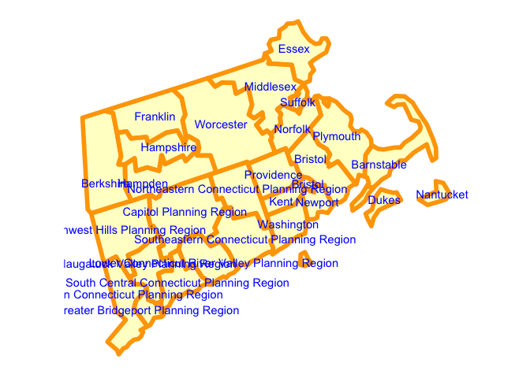

```r
usmap::plot_usmap("counties",
                  include = c("MA", "CT", "RI"),
                  labels = TRUE, label_color = "blue",
                  fill = "yellow", alpha = 0.25, color = "orange", linewidth = 2)
```

Notice in this case we set the `fill` and `alpha` parameters to fill in the counties with a semi-transparent yellow color.

The following parameters are supported:

- `fill`: fill color of the state/county polygons
- `alpha`: transparency of the state/county polygon fill colors
- `color`/`colour`: line color of the state/county polygons
- `linewidth`: thickness of the state/county polygon lines

## Transform data frames to match `usmap` projection

#### Projection

The projection used by `usmap` can also be accessed by using `usmap_crs()`:

```r
usmap::usmap_crs()
```

```
#> Coordinate Reference System:
#>   User input: EPSG:9311
#>   wkt:
#> PROJCRS["NAD27 / US National Atlas Equal Area",
#>     BASEGEOGCRS["NAD27",
#>         DATUM["North American Datum 1927",
#>             ELLIPSOID["Clarke 1866",6378206.4,294.978698213898,
#>                 LENGTHUNIT["metre",1]]],
#>         PRIMEM["Greenwich",0,
#>             ANGLEUNIT["degree",0.0174532925199433]],
#>         ID["EPSG",4267]],
#>     CONVERSION["US National Atlas Equal Area",
#>         METHOD["Lambert Azimuthal Equal Area (Spherical)",
#>             ID["EPSG",1027]],
#>         PARAMETER["Latitude of natural origin",45,
#>             ANGLEUNIT["degree",0.0174532925199433],
#>             ID["EPSG",8801]],
#>         PARAMETER["Longitude of natural origin",-100,
#>             ANGLEUNIT["degree",0.0174532925199433],
#>             ID["EPSG",8802]],
#>         PARAMETER["False easting",0,
#>             LENGTHUNIT["metre",1],
#>             ID["EPSG",8806]],
#>         PARAMETER["False northing",0,
#>             LENGTHUNIT["metre",1],
#>             ID["EPSG",8807]]],
#>     CS[Cartesian,2],
#>         AXIS["easting (X)",east,
#>             ORDER[1],
#>             LENGTHUNIT["metre",1]],
#>         AXIS["northing (Y)",north,
#>             ORDER[2],
#>             LENGTHUNIT["metre",1]],
#>     USAGE[
#>         SCOPE["Statistical analysis."],
#>         AREA["United States (USA) - onshore and offshore."],
#>         BBOX[15.56,167.65,74.71,-65.69]],
#>     ID["EPSG",9311]]
```

A convenience method called `usmap_transform` is provided that transforms a `data.frame` containing longitude/latitude columns to use this projection. (Currently, only `data.frame`s are supported. Other structures may be supported in the future.)

#### Example: earthquakes

Here is an example using the provided `earthquakes` dataset:

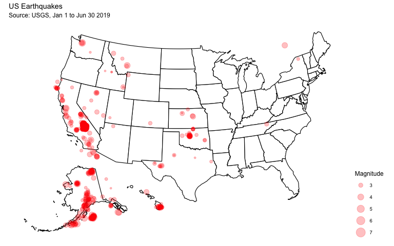

```r
library(usmap)
library(ggplot2)

eq_transformed <- usmap_transform(earthquakes)

plot_usmap() +
  geom_sf(data = eq_transformed, aes(size = mag),
          color = "red", alpha = 0.25) +
  labs(title = "US Earthquakes",
       subtitle = "Source: USGS, Jan 1 to Jun 30 2019",
       size = "Magnitude") +
  theme(legend.position = "right")
```

#### Example: most populous city in each state

And a more comprehensive example using the provided `citypop` dataset:

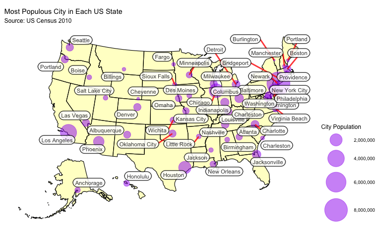

```r
library(usmap)
library(ggplot2)

cities_t <- usmap_transform(citypop)

plot_usmap(fill = "yellow", alpha = 0.25) +
  geom_sf(data = cities_t,
          aes(size = city_pop),
          color = "purple", alpha = 0.5) +
  ggrepel::geom_label_repel(data = cities_t,
                            aes(label = most_populous_city, geometry = geometry),
                            size = 3, alpha = 0.8,
                            label.r = unit(0.5, "lines"), label.size = 0.5,
                            segment.color = "red", segment.size = 1,
                            stat = "sf_coordinates", seed = 1002,
                            max.overlaps = 20) +
  scale_size_continuous(range = c(1, 16),
                        label = scales::comma) +
  labs(title = "Most Populous City in Each US State",
       subtitle = "Source: US Census 2010",
       size = "City Population") +
  theme(legend.position = "right")
```

#### Example: major rivers in the United States

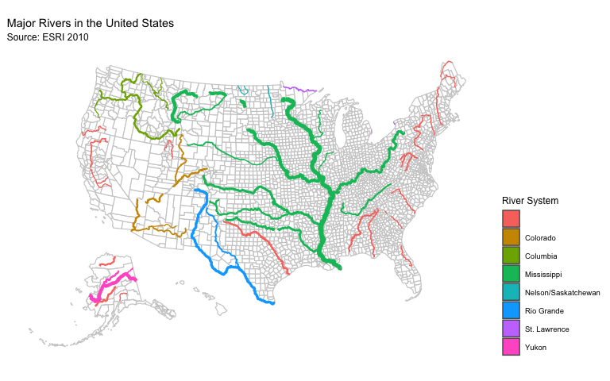

```r
library(usmap)
library(ggplot2)

rivers_t <- usmap_transform(usrivers)

plot_usmap("counties", color = "gray80") +
  geom_sf(data = rivers_t, aes(linewidth = Shape_Length, color = SYSTEM, fill = SYSTEM)) +
  scale_linewidth_continuous(range = c(0.3, 1.8), guide = "none") +
  scale_color_discrete(guide = "none") +
  labs(title = "Major Rivers in the United States",
       subtitle = "Source: ESRI 2010",
       fill = "River System") +
  theme(legend.position = "right")
```

The `usmap_transform` function, combined with the power of `ggplot2` layers can allow for some very unique and complex data visualizations on the US map. The `usmap_transform` function also handles transforming points in the Alaska/Hawaii area so that they are appropriately displayed on their respective states.